# Планировщики событий

Майоров Дмитрий Андреевич

# Информация

## Докладчик

- Майоров Дмитрий Андреевич

# Цель работы

Получение навыков работы с планировщиками событий cron и at.

# Выполнение лабораторной работы

Запускаем терминал и получаем полномочия администратора.

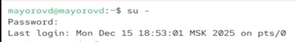

Рисунок 1

# Выполнение лабораторной работы

Смотрим статус демона crond

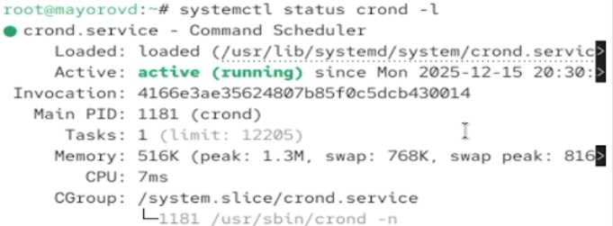

Рисунок 2

# Выполнение лабораторной работы

Смотрим содержимое файла конфигурации /etc/crontab

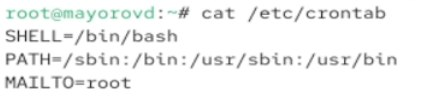

Рисунок 3

# Выполнение лабораторной работы

Смотрим список заданий в расписании. Ничего не отображается, так как расписание еще не задано

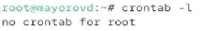

Рисунок 4

# Выполнение лабораторной работы

Открываем файл расписание на редактирование. Добавляем следующую строку в файл распсиания. В этой команде “*/1” обозночает, что команда logger будет выполняться каждую минуту. Звездочки обозначают, что командла будет выполняться каждый час, день месяца, месяц и день недели

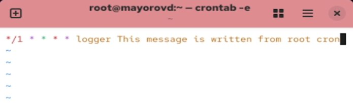

Рисунок 6

# Выполнение лабораторной работы

Еще раз смотрим список заданий в расписании. Появилась запись о запланированном событии

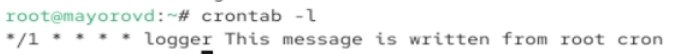

Рисунок 7

# Выполнение лабораторной работы

Через 2 минуты просматриваем журнал системных событий. Запись, добавленная в команду logger корректно записывает сообщения в системный журнал каждую минуту

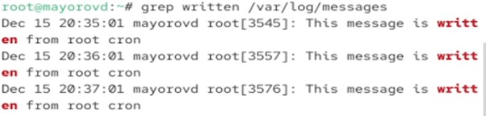

Рисунок 8

# Выполнение лабораторной работы

Изменяем запись в расписании crontab. Здесь “0” обозночает, что команда выполянется в нулевую минуту часа. “*/1” обозначает, что команда выполянется каждый час. Звездочки обозначают, что команда выполняется в лююой день меясца и в любой месяц. “1-5” обозначает, что команда выполняется с понедельика по пятницу.

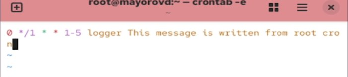

Рисунок 9

# Выполнение лабораторной работы

Смотрим список заданий в расписании. Задание изменилось

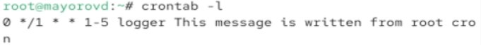

Рисунок 10

# Выполнение лабораторной работы

Переходим в каталог /etc/cron.hourly. Создаем там файл сценария

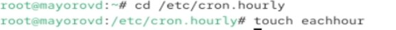

Рисунок 11

# Выполнение лабораторной работы

Открываем файл для редактирования и прописываем в нем следующий скрипт(запись сообщения в системный журнал)

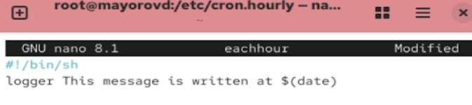

Рисунок 12

# Выполнение лабораторной работы

# Выполнение лабораторной работы

Переходим в каталог /etc/crond.d. Создаем там файл с расписанием

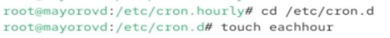

Рисунок 14

# Выполнение лабораторной работы

Открываем этот файл для редактирования и прописываем туда следующую строку. Здесь “11” означает, что команда выполянется в 11-ю минуту часа. Звездочки означают, что команда выполняется каждый час, день месяца, месяц, день недели. “root” означает что команда будет выполняться от имени пользователя root.

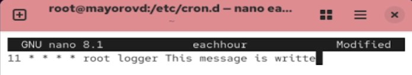

Рисунок 15

# Выполнение лабораторной работы

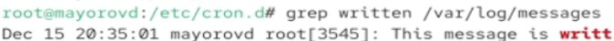

Рисунок 16

# Выполнение лабораторной работы

Запускаем новый терминал. Получаем полномочия администратора. Проверяем, что служба atd загружена и включена

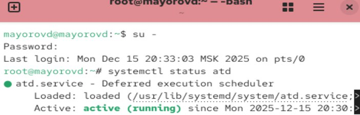

Рисунок 17

# Выполнение лабораторной работы

Задаем выполнение команды logger message from at на нужное нам время. Закрываем оболочку с помощью ctrl+d.

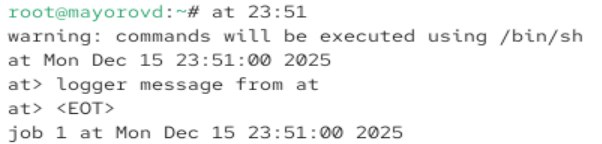

Рисунок 18

# Выполнение лабораторной работы

Убеждаемся, что задание действительно запланировано

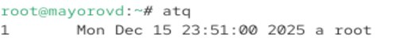

Рисунок 19

# Выполнение лабораторной работы

# Выводы

Мы получили навыки работы с планировщиками событий cron и at.